# Обучение моделей типа Random Forest

Alexey Shovkun

29 сентября 2015 г.

Выделяем обучающую и тестовую выборки. Проверку качества модели в процессе подбора её параметров будем делать с использованием метода перекрестной проверки (cross validation) на обучающей выборке. Тестовая выборка будет использована **только** для оценки качества результирующей модели. Если использовать всю обучающую выборку для выбора модели, то уходит очень много времени на рассчеты. Поэтому *выбор* модели будем делать на 20% от всех обучающих данных. Если при оценке какой-то модели окажется, что ее можно улучшить, увеличив размер обучающей выборки, то у нас будет такая возможность!

Размеры выборок:

- Сокращенная обучающая: 11255 экземпляров.
- проверочная: отсутствует, т.к. применяем кросс-валидацию.
- Сокращенная тестовая: 3749 экземпляров.
- Полная обучающая: 37502 экземпляров.
- Полная тестовая: 12498 экземпляров.

### Регрессия возраста

Представим возраст целым числом и попробуем построить регрессиию.

[output not shown]

```
##    user  system elapsed
##   8.404   0.177  24.293
```

```
## Boosted Generalized Linear Model
##
## 50000 samples
##    40 predictors
##
## No pre-processing
## Resampling: Cross-Validated (10 fold)
##
## Summary of sample sizes: 44999, 45000, 45002, 45000, 45000, 45000, ...
##
## Resampling results across tuning parameters:
##
##   mstop  RMSE      Rsquared   RMSE SD     Rsquared SD
##    50    1.103664  0.2078563  0.01786741  0.03450161
##   100    1.080447  0.2283322  0.01949342  0.03004943
##   200    1.065277  0.2419456  0.02022352  0.02590538
##   300    1.060757  0.2455130  0.02055593  0.02391869
##   500    1.058130  0.2477878  0.02065862  0.02220902
##
## Tuning parameter 'prune' was held constant at a value of no
## RMSE was used to select the optimal model using  the smallest value.
## The final values used for the model were mstop = 500 and prune = no.
```

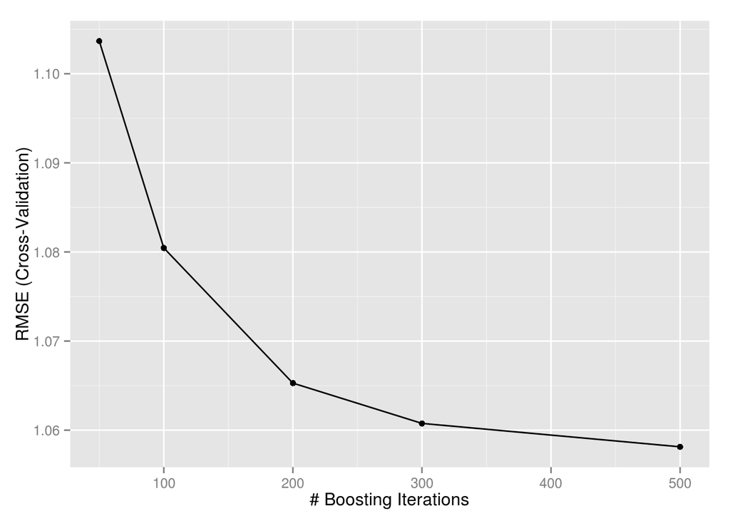

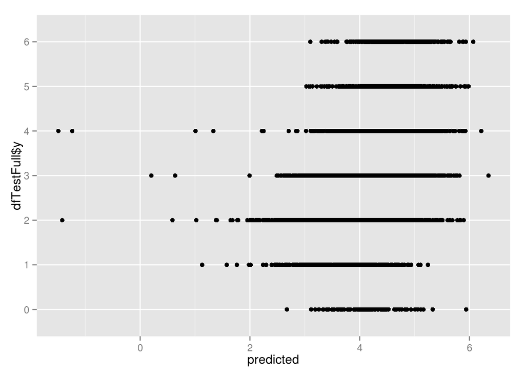

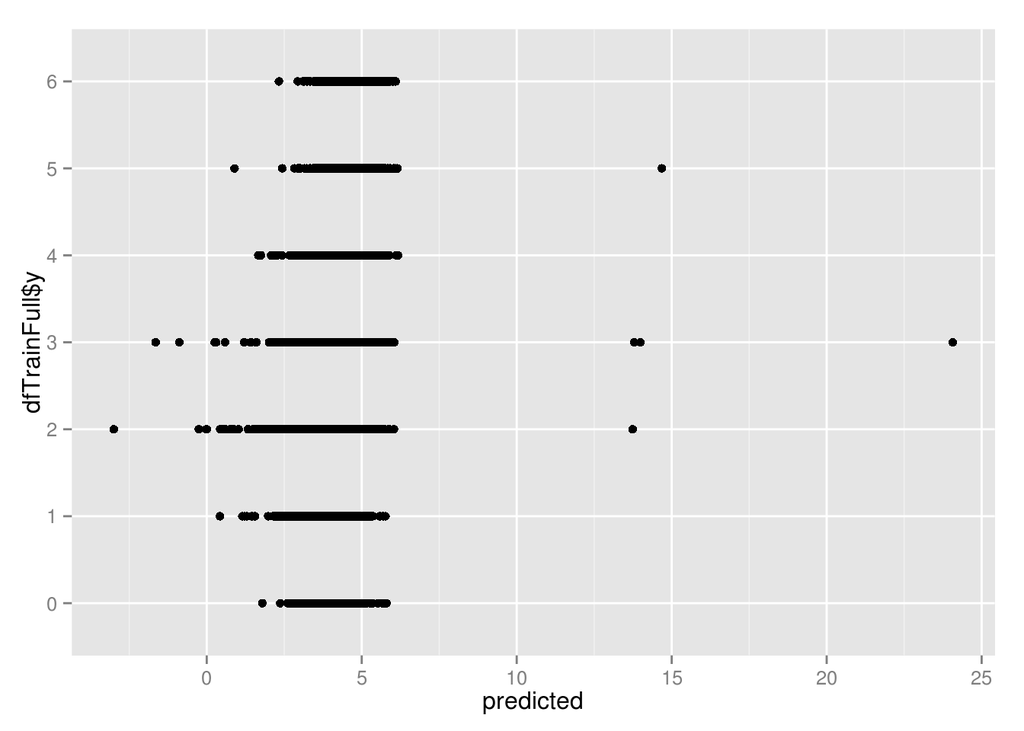

Видим, что модель не очень сильная, особенно плохо работает на редких возрастных группах 0 и 1, но в целом улавливает тренд.

Обновим тренировочные и тестовые датафреймы *предсказанными* линейными значениями возраста.

[output not shown]

### Предсказание редких категорий

?oversampling Все построенные до сих пор модели плохо предсказывают возрастные группы 0 и 1. Вероятно, это связано с тем, что в обучающей выборке мало примеров абонентов из указанных возрастных групп. Проведем теоретически сомнительный эксперимент: “размножим” данные примеров абонентов редких групп таким образом, чтобы количество примеров для абонентов каждой возрастной грпуппы было примерно одинаковым.

```
##
##     0     1     2     3     4     5     6
##   361  1964 15774 14677 10012  5419  1793
```

```
##
##     0     1
## 37231   271
```

```
##
##     0     1
## 37231 37176
```

```
##    user  system elapsed
##  11.737   0.080  25.897
```

```
## Cost-Sensitive C5.0
##
## 74407 samples
##    66 predictors
##     2 classes: '0', '1'
##
## No pre-processing
## Resampling: Cross-Validated (10 fold)
##
## Summary of sample sizes: 66966, 66965, 66967, 66966, 66966, 66966, ...
##
## Resampling results
##
##   Accuracy   Kappa      Accuracy SD  Kappa SD
##   0.9908745  0.9817489  0.001498867  0.002997802
##
## Tuning parameter 'trials' was held constant at a value of 5
##
## Tuning parameter 'winnow' was held constant at a value of FALSE
##
## Tuning parameter 'cost' was held constant at a value of 3
##
```

```
## C5.0Cost variable importance
##
##     Overall
## x37  100.00
## x56  100.00
## x24  100.00
## x8   100.00
## x23  100.00
## x39   99.82
## x30   99.48
## x38   95.08
## x59   92.96
## x43   73.29
## x57   72.46
## x44   68.74
## x35    0.00
```

```
## Confusion Matrix and Statistics
##
##           Reference
## Prediction     0     1
##          0 36874   270
##          1   357 36906
##
##                Accuracy : 0.9916
##                  95% CI : (0.9909, 0.9922)
##     No Information Rate : 0.5004
##     P-Value [Acc > NIR] : < 2.2e-16
##
##                   Kappa : NA
##  Mcnemar's Test P-Value : 0.0005936
##
##             Sensitivity : 0.9927
##             Specificity : 0.9904
##          Pos Pred Value : 0.9904
##          Neg Pred Value : 0.9927
##              Prevalence : 0.4996
##          Detection Rate : 0.4960
##    Detection Prevalence : 0.5008
##       Balanced Accuracy : 0.9916
##
##        'Positive' Class : 1
##
```

```
## Confusion Matrix and Statistics
##
##           Reference
## Prediction     0     1
##          0 12254    80
##          1   154    10
##
##                Accuracy : 0.9813
##                  95% CI : (0.9787, 0.9836)
##     No Information Rate : 0.9928
##     P-Value [Acc > NIR] : 1
##
##                   Kappa : 0.0701
##  Mcnemar's Test P-Value : 1.823e-06
##
##             Sensitivity : 0.1111111
##             Specificity : 0.9875887
##          Pos Pred Value : 0.0609756
##          Neg Pred Value : 0.9935139
##              Prevalence : 0.0072012
##          Detection Rate : 0.0008001
##    Detection Prevalence : 0.0131221
##       Balanced Accuracy : 0.5493499
##
##        'Positive' Class : 1
##
```

Среди результатов сначала видим распределение целевого класса (1 = “Возрастная группа = 0”, 0 = “Возрастная группа <> 0”) до расширения выборки, а потом - после расширения тренировочного набора данных. Расшиение выборки произошло за счет дублирования примеров из класса 1.

Построим модель, предсказывающую возрастную группу 1. Лучше всего конечный результат при C=1, но все равно он хуже, чем без этой модели. Пока не будем ее использовать. Возможно, стоит попробовать другой тип можели для более сильной классификации, например, 2-class SVM.

```
##
##     0     1
## 36157  1345
```

```
##
##     0     1
## 36157 35982
```

```
##    user  system elapsed
##  24.136   0.069  54.736
```

```
## Cost-Sensitive C5.0
##
## 72139 samples
##    66 predictors
##     2 classes: '0', '1'
##
## No pre-processing
## Resampling: Cross-Validated (10 fold)
##
## Summary of sample sizes: 64925, 64925, 64925, 64924, 64925, 64925, ...
##
## Resampling results
##
##   Accuracy   Kappa      Accuracy SD  Kappa SD
##   0.9875241  0.9750489  0.001160175  0.002320198
##
## Tuning parameter 'trials' was held constant at a value of 10
##
## Tuning parameter 'winnow' was held constant at a value of FALSE
##
## Tuning parameter 'cost' was held constant at a value of 1
##
```

```
## Confusion Matrix and Statistics
##
##           Reference
## Prediction     0     1
##          0 35809   149
##          1   348 35833
##
##                Accuracy : 0.9931
##                  95% CI : (0.9925, 0.9937)
##     No Information Rate : 0.5012
##     P-Value [Acc > NIR] : < 2.2e-16
##
##                   Kappa : NA
##  Mcnemar's Test P-Value : < 2.2e-16
##
##             Sensitivity : 0.9959
##             Specificity : 0.9904
##          Pos Pred Value : 0.9904
##          Neg Pred Value : 0.9959
##              Prevalence : 0.4988
##          Detection Rate : 0.4967
##    Detection Prevalence : 0.5015
##       Balanced Accuracy : 0.9931
##
##        'Positive' Class : 1
##
```

```
## Confusion Matrix and Statistics
##
##           Reference
## Prediction     0     1
##          0 11816   207
##          1   234   241
##
##                Accuracy : 0.9647
##                  95% CI : (0.9613, 0.9679)
##     No Information Rate : 0.9642
##     P-Value [Acc > NIR] : 0.3798
##
##                   Kappa : 0.5039
##  Mcnemar's Test P-Value : 0.2157
##
##             Sensitivity : 0.53795
##             Specificity : 0.98058
##          Pos Pred Value : 0.50737
##          Neg Pred Value : 0.98278
##              Prevalence : 0.03585
##          Detection Rate : 0.01928
##    Detection Prevalence : 0.03801
##       Balanced Accuracy : 0.75926
##
##        'Positive' Class : 1
##
```

### Случайный лес (Random Forest, rf)

RF.

[output not shown]

```
##     user   system  elapsed
##  112.017    0.486 1134.650
```

```
## Random Forest
##
## 50000 samples
##    65 predictors
##     7 classes: '0', '1', '2', '3', '4', '5', '6'
##
## No pre-processing
## Resampling: Cross-Validated (10 fold)
##
## Summary of sample sizes: 44999, 44999, 45001, 45000, 45001, 45001, ...
##
## Resampling results across tuning parameters:
##
##   mtry  Accuracy   Kappa      Accuracy SD  Kappa SD
##   21    0.7699800  0.6934130  0.003763705  0.004927048
##   35    0.7717201  0.6961647  0.004835008  0.006495274
##   37    0.7718599  0.6964072  0.005615650  0.007523801
##   39    0.7715801  0.6960768  0.005403523  0.007072891
##   41    0.7718001  0.6964386  0.003973932  0.005249353
##   43    0.7716403  0.6961218  0.004653586  0.006177111
##   45    0.7716801  0.6962756  0.005411156  0.007231094
##   70    0.7717802  0.6964900  0.005434238  0.007178927
##
## Accuracy was used to select the optimal model using  the largest value.
## The final value used for the model was mtry = 37.
```

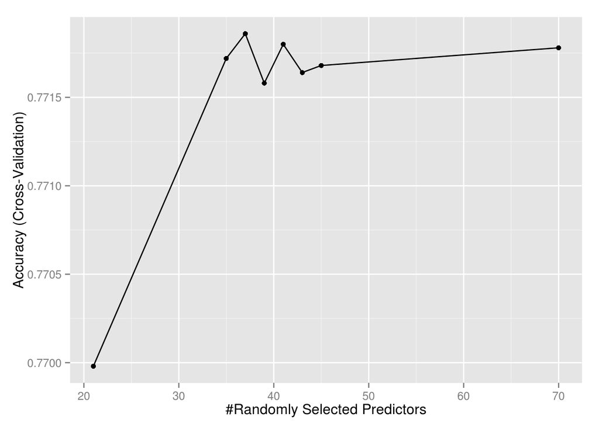

```
##
## Call:
##  randomForest(x = x, y = y, ntree = ..1, mtry = param$mtry)
##                Type of random forest: classification
##                      Number of trees: 100
## No. of variables tried at each split: 37
##
##         OOB estimate of  error rate: 22.94%
## Confusion matrix:
##     0   1     2     3    4    5    6 class.error
## 0 149  10    41    76   53   29    3   0.5872576
## 1   8 579   531   383  371   77   15   0.7051935
## 2   4 167 12893  1496  786  405   23   0.1826423
## 3  27  29  1262 12151  836  338   34   0.1721060
## 4   5  60   832  1033 7546  495   41   0.2463044
## 5   1  17   598   556  537 3655   55   0.3255213
## 6   0   5    49    84   55   43 1557   0.1316230
```

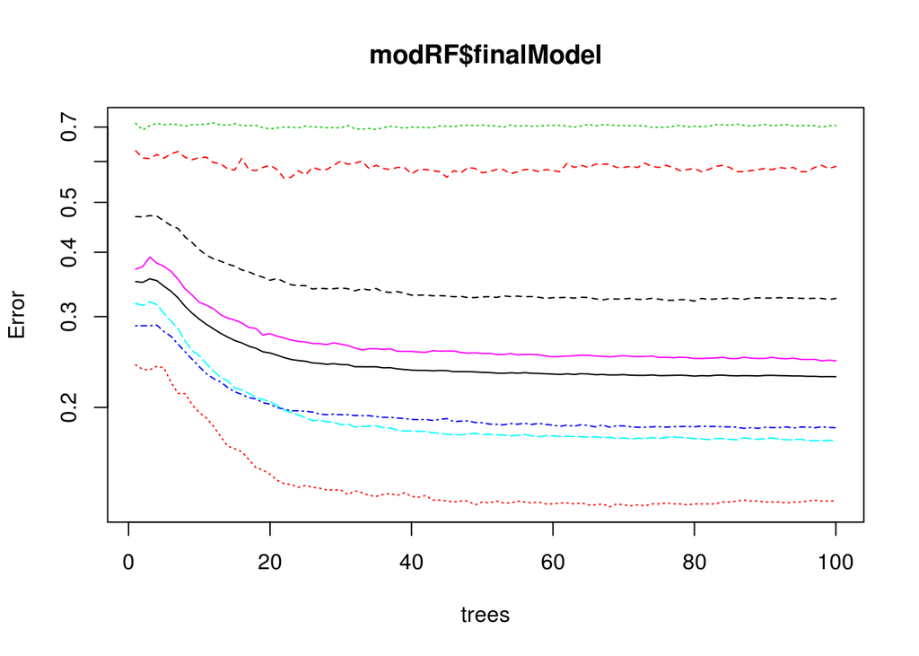

```
##        Overall varName
## 1  100.0000000      x8
## 2   16.6185096    yLin
## 3   10.9405333     y61
## 4    9.8629945     x57
## 5    7.0755401     x56
## 6    6.5939845     x30
## 7    6.5257312     x58
## 8    5.1747804     x29
## 9    4.5353426     x23
## 10   4.2621061     x59
## 11   3.7009908     x37
## 12   3.5497269     x54
## 13   3.4973726     x61
## 14   3.4239754     x24
```

[output cut: 36 more lines]

?Попытка обучить случайный лес на сокращенном наборе наиболее значимых параметров дает менее точный результат.

Проведем анализ сдвига/разброса на основе Случайного леса c параметром mtry =37.

Чтобы побороть проблему переобучения, можно применть следующее:

- регуляризация (см. далее),
- уменьшить количество деревьев,
- попробовать на полной обучающей выборке,
- метод bagging,
- больше данных,
- сокращение (отбор) параметров.

Поскольку данная модель показывает адекватные результаты, выделим параметры абонента, которые для нее оказались важными. Будем использовать этот набор параметров в случаях, когда другие модели будут показывать высокий разброс.

## Предсказние новых

Результаты публикации:

- для модели Случайный лес (rf) точность оказалась **74.91%**. Показатель невысокий, однако это первая публикация и она показала, что применяемый для выбора модели подход для оценки точности предстказания работает хорошо - в реальности точность оказалась даже чуть лучше, чем ожидалось.
- для модели (LogitBoost) точность оказалась **70.81%**. Низкая точность обусловлена спефикой модели (NA в предсказанных классах). - для модели случайный лес на данных CSMNR (NA в категориях заменены на константу, категории в длинных переменных (> 5 категорий) заменены на наиболее вероятный для них класс, NA в новых категориях тестового примера также заменены на константу, числовые переменные преобразованы линейно в диапазон [0,1] ) точность оказалась **75.73%**.
- для модели случайный лес, аналогичной предыдущей, к которой был добавлен предсказанный непрерывный параметр возраста (yLin), точность оказалась **75.77** .
- для модели случайный лес, аналогичной предыдущей, к которой был добавлен предсказанный бинарный параметр, показывающий принадлежность к возрастной группе 0 (y0), точность оказалась **76.07%**.

увеличить nTree